# Section 10: Borrowing a Deep Network

GOVT 6039 | Fall 2026 | Discussion section, 18 November 2026 | Instructor version

Lecture 18 ended with a rule for when networks win: not on tabular data with a few meaningful features, where boosting is hard to beat, but on **raw, high-dimensional inputs with structure (pixels, words, audio)**, where we cannot hand-build the basis functions. Lecture 19 then trained a network on 21,844 handwritten digits and topped out at 72%. Words are harder than digits, and a political scientist rarely has 21,844 hand-coded sentences.

So in practice we **borrow** a network that someone else trained. Today’s is XLM-R-ParlaSent (Mochtak, Rupnik, Kuzman & Ljubešić 2025). It starts from XLM-R, a 24-layer network trained to fill in missing words in text in 100 languages (Conneau et al. 2020). The ParlaMint project then trained it further on 1.72 billion words of proceedings from 26 European parliaments, and finally fitted it to sentences hand-coded for sentiment. The question for the section: **can a network trained by someone else measure the tone of parliamentary speech, and when should you trust it?**

The data are ParlaSent 1.0 (Mochtak, Rupnik & Ljubešić 2023): sentences from parliamentary debates, each coded by trained annotators on a six-point scale that we score from 0 to 5:

| $y$ | 0 | 1 | 2 | 3 | 4 | 5 |
| --- | --- | --- | --- | --- | --- | --- |
| Code | Negative | Mostly negative | Neutral, leaning negative | Neutral, leaning positive | Mostly positive | Positive |

There are five **training files** of 2,600 sentences each (Bosnia–Croatia–Serbia, Czechia, Slovakia, Slovenia, the UK), coded by two annotators and reconciled, which the network was fitted to; and two **test files** of 2,600 sentences each (Bosnia–Croatia–Serbia and the UK), coded by one annotator, which it never saw. We use four of the files:

| `file` | Sentences | Used for |
| --- | --- | --- |
| `EN` | 2,600 from the UK House of Commons and Lords, training file | fitting our own bag-of-words model (Part 2) |
| `EN_test` | 1,500 of the 2,600 from the UK, test file | testing (Parts 1, 2 and 4) |
| `BCS_test` | 1,500 of the 2,600 from Bosnia and Herzegovina, Croatia and Serbia, test file | testing in other languages (Parts 2 and 4) |
| `CZ` | 2,000 of the 2,600 from the Czech Chamber of Deputies, training file | your own small coding project (Part 3) |

Each row also records the speaker’s `party`, `gender`, the `date`, and `ruling`: whether the speaker’s party was in government (“Coalition”) or in opposition at the time.

## Getting this running

```bash
git clone --filter=blob:none --sparse https://github.com/ddekadt/cornell-govt-6039.git
cd cornell-govt-6039
git sparse-checkout set sections/section10
cd sections/section10
quarto render section10_instructor.qmd
```

The R packages are `ggplot2`, `patchwork`, `Matrix`, `glmnet` and `nnet`. Nothing here needs Python or a GPU. Running a 24-layer network on 5,000 sentences takes 20 to 50 minutes on a laptop CPU, so it was done once by `prep_embeddings.py` and the outputs are saved in `data/cache/`. To keep that run short we use a random 1,500 sentences from each test file and 2,000 from the Czech file. `prep_data.R` builds `data/parlasent.csv` from the original files in `data/raw/`. Everything else below runs in under a minute.

```r
ps <- read.csv("data/parlasent.csv", stringsAsFactors = FALSE)
A    <- readRDS("data/cache/A_test.rds")              # network A on 1,500 sentences from each test file
test <- ps[ps$file %in% c("EN_test", "BCS_test"), ][A$row, ]   # the same sentences, in the same order
hd   <- readRDS("data/cache/A_head.rds")              # network A's last two layers
table(test$file, test$country)
```

```
            BiH   HR  SRB   UK
  BCS_test   97  775  628    0
  EN_test     0    0    0 1500
```

# Part 1: the network in our notation

The network (Lectures 18 and 19)

**Input.** A sentence $x$, split into word pieces.

**Layers 1 to 24 (pretrained).** Each layer builds its derived features from the layer before, as in Lecture 19’s deep network. The last layer hands on $p = 1{,}024$ numbers for the sentence as a whole, $u(x) = (u_1(x), \dots, u_{1024}(x))$. Call them the **borrowed features**.

**Layer 25: the hidden layer of Lecture 18.** $J = 1{,}024$ derived features, each a weighted mix of every borrowed feature, bent by an activation:
$$b_j(x) = g\Big(w_{j0} + \sum_{k=1}^{1024} w_{jk}\, u_k(x)\Big), \qquad g(z) = \tanh(z) = 2\,\operatorname{logit}^{-1}(2z) - 1 .$$
The $\tanh$ is the sigmoid of Lecture 18, stretched to run from $-1$ to $1$.

**Output.** Sentiment is a score, not a class, so the output is a linear regression on the derived features, fitted by least squares (`nnet`’s `linout = TRUE`):
$$\hat y(x) = \beta_0 + \sum_{j=1}^{1024} \beta_j\, b_j(x).$$

**Training.** XLM-R’s weights were trained to predict masked words; ParlaMint continued that on parliamentary text; then all the weights, layers 1 to 24 included, were updated by SGD on the coded ParlaSent training sentences (**fine-tuning**).

So the last two layers are exactly the one-hidden-layer network from Lecture 18. What is new is that its inputs are not features we chose, like turnout, but derived features learned by 24 layers from text.

**1.1** How many weights are in layers 25 and the output, using Lecture 18’s formula $(p + 1)J + J + 1$? XLM-R-large has about 560 million weights in all. How many numbers would the curvature matrix $H$ of Lecture 19’s quasi-Newton update hold for the whole network? What does that tell you about how it was trained?

```r
p <- 1024; J <- 1024
n_head <- (p + 1) * J + J + 1
c(head = n_head, H_head = n_head^2, H_all = 560e6^2)
```

```
        head       H_head        H_all
1.050625e+06 1.103813e+12 3.136000e+17
```

**Answer**

The last two layers alone have $(1{,}024 + 1) \times 1{,}024 + 1{,}024 + 1 = 1,050,625$ weights, against 131 for the turnout network in Lecture 18. For the whole network $H$ would hold $(5.6 \times 10^8)^2 \approx 3 \times 10^{17}$ numbers, which no computer can store, let alone invert at every update. So it was trained the way Lecture 19 trained the wide network: SGD on minibatches, one slope per weight from backpropagation, no curvature. The tuning parameters are the ones in Lecture 19’s table: the step size $\alpha$, the minibatch size $n_b$ and the number of epochs (the ParlaSent model used 4 epochs, minibatches of 32 and $\alpha = 8 \times 10^{-6}$), with dropout inside every layer.

**1.2** `A$u` holds the borrowed features $u(x)$ for the first 20 of our test sentences, and `hd` holds the weights of layer 25 and the output. Run the forward pass of the last two layers yourself, as in Lecture 18’s design matrix, and check that you get the network’s own $\hat y$.

```r
# hd$W: J x p matrix of w_jk; hd$w0: the J intercepts w_j0; hd$beta, hd$beta0: the output layer
u     <- A$u[1:5, ]                                              # 5 sentences x 1,024 borrowed features
b     <- tanh(sweep(u %*% t(hd$W), 2, hd$w0, "+"))           # 5 x 1,024 derived features b_j(x)
y_hat <- hd$beta0 + drop(b %*% hd$beta)                      # the output layer

data.frame(sentence = substr(test$sentence[1:5], 1, 70), coder = test$y[1:5],
           ours = round(y_hat, 3), network = round(A$yhat[1:5], 3))
```

```
                                                                sentence coder
1 It drives cost in the way that deprivation does, and we must make the      0
2 and learned Lady’s first comment about the number, the scheme is still     3
3 Friend and members of the British Hedgehog Preservation Society to dis     3
4 For unsecured creditors, the new moratorium can be accessed only if th     2
5 I am proud to be a Minister sitting on the Front Bench among many othe     5
   ours network
1 0.637   0.637
2 3.035   3.035
3 4.016   4.016
4 2.069   2.069
5 5.405   5.405
```

**Answer**

Our two matrix products reproduce the network’s predictions up to rounding: the largest difference is 1e-07, because the network computes in single precision. Nothing about the last two layers is mysterious: they are a design matrix of derived features and a regression on it, exactly as in Lecture 18. Everything hard is hidden inside $u(x)$: the 24 layers that turn a sentence into 1,024 numbers in which “positive” and “negative” speech can be separated by a few bends. Note also that the human codes are integers and $\hat y$ is not: the network is a regression, so it can return 2.6 for a sentence a coder could only call 2 or 3, and nothing keeps it inside the scale (the fifth sentence scores 5.40). For a measure on a bounded scale you might clip it to $[0, 5]$; for comparing groups, leaving it unclipped is fine.

# Part 2: does a borrowed network measure well?

We score predictions on the test sentences three ways: $R^2 = 1 - \sum_i (y_i - \hat y_i)^2 / \sum_i (y_i - \bar y)^2$, the mean absolute error, and the correlation between $\hat y$ and $y$.

```r
r2   <- function(y, yhat) 1 - sum((y - yhat)^2) / sum((y - mean(y))^2)
mae  <- function(y, yhat) mean(abs(y - yhat))
score <- function(y, yhat) c(R2 = r2(y, yhat), MAE = mae(y, yhat), cor = cor(y, yhat))

uk  <- test$file == "EN_test"; bcs <- test$file == "BCS_test"
net <- rbind(UK = score(test$y[uk], A$yhat[uk]), BCS = score(test$y[bcs], A$yhat[bcs]))
round(net, 3)
```

```
       R2   MAE   cor
UK  0.658 0.693 0.834
BCS 0.577 0.730 0.798
```

To know whether that is good, we need two comparisons. The first is the model a political scientist would fit without a borrowed network: a ridge regression on word counts, the **bag of words**, trained on the 2,600 coded UK training sentences, with $\lambda$ chosen by 10-fold CV.

```r
# lower-case words (any alphabet); keep words that appear in at least 3 training sentences
words_of <- function(s) regmatches(tolower(s), gregexpr("\\p{L}+", tolower(s), perl = TRUE))
bow <- function(sentences, vocab) {
  w <- words_of(sentences)
  i <- rep(seq_along(w), lengths(w)); j <- match(unlist(w), vocab)
  keep <- !is.na(j)
  sparseMatrix(i = i[keep], j = j[keep], x = 1, dims = c(length(w), length(vocab)), dimnames = list(NULL, vocab))
}
train_en <- ps[ps$file == "EN", ]
df_w  <- table(unlist(lapply(words_of(train_en$sentence), unique)))
vocab <- names(df_w)[df_w >= 3]
X_tr  <- bow(train_en$sentence, vocab)

set.seed(6039)
fit_bow <- cv.glmnet(X_tr, train_en$y, alpha = 0)            # ridge, lambda by 10-fold CV
p_bow   <- drop(predict(fit_bow, bow(test$sentence, vocab), s = "lambda.min"))

bow_sc <- rbind(UK = score(test$y[uk], p_bow[uk]), BCS = score(test$y[bcs], p_bow[bcs]))
round(bow_sc, 3)
```

```
       R2   MAE   cor
UK  0.127 1.374 0.453
BCS 0.010 1.484 0.122
```

```r
# how much of a BCS sentence does the English vocabulary see?
hits <- rowSums(bow(test$sentence[bcs], vocab))
c(words_per_sentence = mean(lengths(words_of(test$sentence[bcs]))), in_vocab = mean(hits), share_none = mean(hits == 0))
```

```
words_per_sentence           in_vocab         share_none
            19.156              1.304              0.294
```

The second comparison is a **second human coder**. In the training files two annotators coded every sentence independently before reconciling. How well does one coder’s code predict the other’s?

```r
two <- ps[ps$file %in% c("EN", "CZ"), ]
coders <- rbind(UK = score(two$y_a1[two$file == "EN"], two$y_a2[two$file == "EN"]),
                CZ = score(two$y_a1[two$file == "CZ"], two$y_a2[two$file == "CZ"]))
round(coders, 3)
```

```
      R2   MAE   cor
UK 0.654 0.588 0.824
CZ 0.461 0.613 0.758
```

**2.1** Put the three together. On UK sentences, how does the borrowed network compare with the bag of words, and with a second trained coder? The ParlaSent authors report a test $R^2$ of 0.67 on the UK file and 0.61 on the BCS file; do we reproduce them?

**Answer**

On the UK test sentences the network reaches $R^2 = 0.66$ (correlation 0.83), against 0.13 for a ridge regression on 2,372 word counts fitted to 2,600 coded UK sentences. Two trained coders working independently on the UK training sentences agree with a correlation of 0.82 (0.76 on Czech ones). So on UK speech the network agrees with a coder about as closely as a second coder does, and the bag of words is far behind both. Our $R^2$ of 0.66 and 0.58 are close to the published 0.67 and 0.61; we use a random 1,500 sentences from each test file, so small differences are expected, and getting close is a useful check that we are running the model we think we are.

A caveat on “as good as a coder”: the coders’ agreement is measured on the training files, the network’s on the test files, which only one annotator coded. Single-coder labels are noisier than reconciled ones, which works against the network in this comparison, not for it.

**2.2** Now the BCS sentences. The bag of words was trained on English; why does it do what it does on Bosnian, Croatian and Serbian? Why does the network not have the same problem, even though its last two layers were fitted mostly to sentences from other parliaments?

**Answer**

On BCS sentences the bag of words has $R^2 = 0.01$: barely better than predicting one number for everyone. A BCS sentence has 19.2 words on average, of which 1.3 are in the English vocabulary, and 29% of sentences have none at all. The words that do match are mostly accidents of spelling: Croatian and Serbian *i* (“and”), *a* (“but”), *to* (“that”) and *do* (“until”) look like English words but mean something else. Its basis functions are English words, and they do not travel.

The network’s basis functions are not words. Its 24 layers were trained on text in 100 languages to predict missing words, and a representation in which sentences that mean similar things get similar $u(x)$, whatever their language, turns out to be useful for that. The sentiment layers then work from $u(x)$, so they work on BCS sentences too ($R^2 = 0.58$), even though most of the coded sentences they were fitted to came from other parliaments. This is the practical case for borrowing: the features were learned from billions of words that nobody had to code.

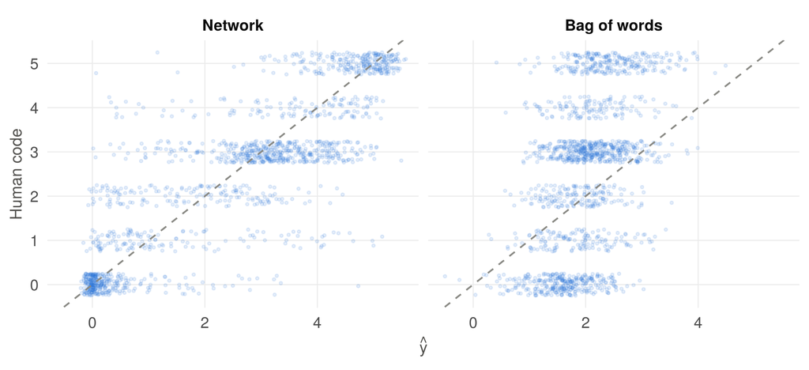

Figure 1: Human code against prediction on the UK test sentences, jittered. Left: the borrowed network. Right: ridge on word counts. Dashed: perfect prediction.

# Part 3: your own parliament, with few codes

Now the situation you are more likely to be in. You study the Czech Chamber of Deputies and can afford to code $n$ sentences yourself. Network A was fine-tuned on Czech sentiment codes, so for this exercise it has seen the answers. Instead we borrow **network B**, XLM-R-parla: the same 24 layers after the ParlaMint training on parliamentary text, but **before** any sentiment codes. It has never seen a sentiment label. It was also never trained to summarise a sentence at the start token (that was part of network A’s fine-tuning), so for network B we take $u(x)$ to be the average of its last layer over the sentence’s word pieces. We keep these borrowed features fixed (**frozen**) and fit only a new output layer on our $n$ coded sentences: ridge regression of $y$ on the 1,024 features. We hold out 1,000 of our 2,000 Czech sentences for testing, and draw training samples of size $n$ from the other 1,000.

```r
B   <- readRDS("data/cache/B_cz.rds")              # network B on 2,000 Czech sentences
cz  <- ps[ps$file == "CZ", ][B$row, ]
U_B <- B$u                                         # 2,000 x 1,024 borrowed features (mean over word pieces)
set.seed(6039)
te  <- sample(nrow(cz), 1000); pool <- setdiff(seq_len(nrow(cz)), te)
```

```r
# For each n: draw n coded sentences, fit ridge (lambda by 5-fold CV) on (a) word counts, (b) frozen u(x);
# score on the 1,000 held-out sentences. Five draws per n. About 30 seconds.
fit_score <- function(X, y, Xte, yte) {
  f <- cv.glmnet(X, y, alpha = 0, nfolds = 5)
  r2(yte, drop(predict(f, Xte, s = "lambda.min")))
}
ns <- c(50, 100, 200, 500, 1000)
curve <- do.call(rbind, lapply(ns, function(n) do.call(rbind, lapply(1:5, function(r) {
  set.seed(1000 * n + r)
  tr <- if (n == length(pool)) pool else sample(pool, n)
  v  <- names(which(table(unlist(lapply(words_of(cz$sentence[tr]), unique))) >= 2))
  data.frame(n = n, rep = r,
             `Bag of words` = fit_score(bow(cz$sentence[tr], v), cz$y[tr], bow(cz$sentence[te], v), cz$y[te]),
             `Borrowed features` = fit_score(U_B[tr, ], cz$y[tr], U_B[te, ], cz$y[te]),
             check.names = FALSE)
}))))
lc <- aggregate(cbind(`Bag of words`, `Borrowed features`) ~ n, data = curve, FUN = mean)
round(lc, 3)
```

```
     n Bag of words Borrowed features
1   50       -0.055             0.033
2  100       -0.013             0.115
3  200        0.003             0.217
4  500        0.020             0.307
5 1000        0.032             0.350
```

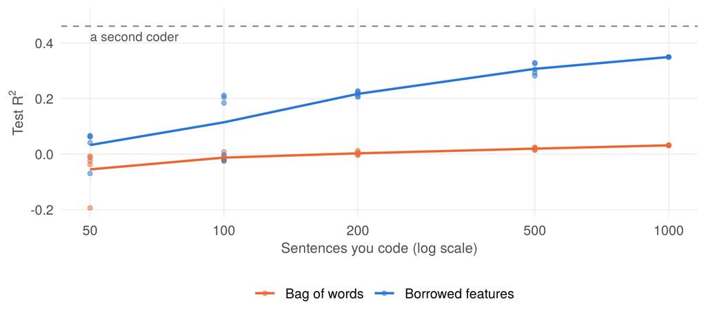

Figure 2: Test R² on 1,000 held-out Czech sentences, by the number of sentences you code. Points: five random draws; lines: their mean. Dashed: how well one Czech coder’s codes predict the other’s.

**3.1** Read the curve. How many sentences would you have to code for the bag of words to match what the borrowed features achieve with 100? Why are the borrowed features so much better with few codes, given that network B was never trained on sentiment?

**Answer**

With 100 coded sentences, ridge on the frozen features reaches a test $R^2$ of 0.11; the bag of words reaches -0.01, and even with all 1,000 sentences only 0.03. Within the range we tried, the bag of words never gets started, and the borrowed features with 100 codes beat it with 1,000.

The reason is the one from Lecture 18: the model is only as good as its basis functions. With word counts, every word is its own feature. Czech inflects heavily, so the same word turns up in many forms, and with a few hundred sentences most forms appear once or twice: ridge has almost nothing to estimate their weights from, and *katastrofa* and *katastrofální* are unrelated columns. Network B’s 24 layers were trained to predict missing words in parliamentary speech, which forces them to represent what a sentence is doing (thanking, blaming, objecting) in a way that does not depend on the exact word forms. Some of that is close to linear in $u(x)$, and that is what our ridge regression picks up.

But be honest about the level. With 1,000 codes the frozen features reach 0.35, below the 0.46 with which one Czech coder predicts the other, and well below what network A reaches on the test files (0.66 and 0.58). That gap is what network A’s fine-tuning bought: all 560 million weights updated on the 13,000 coded sentences of the five training files. So the order of preference is: (1) a network already fine-tuned for your task and validated on speech like yours; (2) frozen features from a related network plus a few hundred of your own codes, as a start; (3) a bag of words, only with thousands of codes.

**3.2** Why ridge on the 1,024 features rather than `nnet` with a hidden layer, as in Lecture 18? Fit `nnet` on the first 20 principal components of $u(x)$ with $n = 200$, and compare it with ridge on the same 200 sentences.

```r
set.seed(6039); tr <- sample(pool, 200)
pcs <- prcomp(U_B[tr, ], center = TRUE, scale. = FALSE, rank. = 20)   # PCs from the 200 coded sentences only
Z   <- scale(pcs$x); Z_te <- scale(predict(pcs, U_B[te, ]), attr(Z, "scaled:center"), attr(Z, "scaled:scale"))

nn_r2 <- sapply(c(0.1, 1, 10), function(lam) {
  set.seed(6039)
  fits <- lapply(1:5, function(s) nnet(Z, cz$y[tr], size = 5, decay = lam, linout = TRUE, maxit = 500, trace = FALSE))
  best <- fits[[which.min(sapply(fits, `[[`, "value"))]]   # keep the best of five random starts
  r2(cz$y[te], drop(predict(best, Z_te)))
})
c(weights_nnet_1024 = (1024 + 1) * 5 + 5 + 1, weights_nnet_20 = (20 + 1) * 5 + 5 + 1)
```

```
weights_nnet_1024   weights_nnet_20
             5131               111
```

```r
set.seed(6039); ridge_200 <- fit_score(U_B[tr, ], cz$y[tr], U_B[te, ], cz$y[te])
round(c(nnet_decay_0.1 = nn_r2[1], nnet_decay_1 = nn_r2[2], nnet_decay_10 = nn_r2[3], ridge_1024 = ridge_200), 3)
```

```
nnet_decay_0.1   nnet_decay_1  nnet_decay_10     ridge_1024
        -1.134         -0.192          0.144          0.192
```

**Answer**

A hidden layer of five on all 1,024 features would already have 5,131 weights to estimate from 200 sentences. On 20 principal components it has 111, and with enough weight decay it gets close to, but does not beat, ridge on all 1,024 features (0.14 against 0.19). The bends were worth having in Lecture 18 because turnout entered the outcome non-linearly. Here the 24 layers have already done the bending; what is left is close to linear, so the extra flexibility mostly adds variance. The general lesson: with a borrowed network, start with a linear output layer on frozen features (the cheapest **probe**), and add a hidden layer, or fine-tune all the weights as the ParlaSent authors did, only when you have the codes to pay for it.

# Part 4: does the opposition sound more negative?

A measure is only useful if it gets the comparisons right, and the comparisons are where measurement error bites. A standing claim about parliaments is that opposition MPs speak more negatively than government MPs. The test files record each speaker’s status in `ruling`, so we can compute that gap with the human codes and with the network’s scores. First, though, check the covariate.

**4.1** Tabulate `ruling` by party and year for the two largest UK parties. Which party governed the UK in each of these years? What has gone wrong, and how would you fix it?

```r
uk_t <- test[uk & test$party %in% c("Conservative", "Labour"), ]
with(uk_t, table(paste(party, substr(date, 1, 4)), ruling))
```

```
                   ruling
                    Coalition Opposition
  Conservative 2015        28         77
  Conservative 2016         0        123
  Conservative 2017         0        116
  Conservative 2018         0        128
  Conservative 2019         0        119
  Conservative 2020         0        162
  Conservative 2021         0         30
  Labour 2015               0         67
  Labour 2016               0         78
  Labour 2017               0         57
  Labour 2018               0         82
  Labour 2019               0         55
  Labour 2020               0         58
  Labour 2021               0         10
```

**Answer**

The Conservatives governed throughout: in coalition with the Liberal Democrats until May 2015, then alone. Yet every Conservative sentence after 2015 is labelled “Opposition”, so `ruling` codes whether the speaker’s party was in a **coalition** government, and a single-party government counts as not ruling. Taken at face value, the UK “gap” would compare Conservatives in 2015 with everyone else, mostly other Conservatives. The fix is to recode government status from party and date, which takes one line, and to report how many rows changed. A network can only measure the outcome; it cannot fix the covariate, and nothing in the network’s accuracy would have warned us.

```r
test$gov <- test$ruling == "Coalition"                                  # BCS parliaments: keep as coded
test$gov[uk] <- test$party[uk] == "Conservative" |
                (test$party[uk] == "Liberal Democrat" & test$date[uk] < "2015-05-08")
test$gov[uk & test$party %in% c("Crossbench", "Bishops", "Non-affiliated")] <- NA   # Lords outside both sides
c(rows_changed_UK = sum(test$gov[uk] != (test$ruling[uk] == "Coalition"), na.rm = TRUE),
  set_missing_UK  = sum(uk & is.na(test$gov)))
```

```
rows_changed_UK  set_missing_UK
            755              88
```

**4.2** Now compute, for each parliament, the opposition-minus-government gap in mean sentiment with the coders’ scores and with the network’s, and the same gap in the network’s error $\hat y - y$. Does the network recover the coders’ gaps? What does the last column tell you?

```r
gap <- function(v, g) mean(v[!g], na.rm = TRUE) - mean(v[g], na.rm = TRUE)   # opposition minus government
se_gap <- function(v, g) sqrt(var(v[!g]) / sum(!g) + var(v[g]) / sum(g))       # its standard error
gaps <- do.call(rbind, lapply(split(seq_len(nrow(test)), test$country), function(i) {
  g <- test$gov[i]; ok <- !is.na(g)
  data.frame(parliament = test$country[i][1], sentences = sum(ok),
             coders = gap(test$y[i][ok], g[ok]), network = gap(A$yhat[i][ok], g[ok]),
             error_gap = gap(A$yhat[i][ok] - test$y[i][ok], g[ok]),
             se_error_gap = se_gap(A$yhat[i][ok] - test$y[i][ok], g[ok]))
}))
gaps[, 3:6] <- round(gaps[, 3:6], 2)
gaps
```

```
    parliament sentences coders network error_gap se_error_gap
BiH        BiH        84  -0.08   -0.07      0.01         0.25
HR          HR       673  -0.61   -0.57      0.04         0.08
SRB        SRB       540  -0.86   -0.66      0.21         0.10
UK          UK      1412  -0.72   -0.80     -0.08         0.05
```

```r
# the UK gap with `ruling` as coded, for comparison
gap_uk_raw <- gap(test$y[uk], test$ruling[uk] == "Coalition")
```

[output not shown]

**Answer**

The last column is the one to read before using $\hat y$ as an outcome. If the network’s error $\hat y - y$ were unrelated to government status, the network’s gap would equal the coders’ gap, however noisy each sentence’s score. In the UK and Croatia the error gap is small (-0.08 and 0.04). In Serbia it is 0.21, about two standard errors (its standard error is 0.10): the network scores opposition speech as less negative than the coders do, relative to government speech, so it may understate the Serbian gap by about a quarter (-0.66 against -0.86). With 540 sentences this is suggestive rather than settled, which is the point: you need coded sentences from each group to find out. An $R^2$ of 0.58 does not tell you this; only coded sentences from the groups you want to compare can. In practice: code a few hundred sentences from each group, and check the error gap before you report the network’s.

With `ruling` as coded, the UK gap would have been -0.59 instead of -0.72, a comparison of pre-May-2015 coalition speakers with everyone else, which is close enough to look plausible and still answers a different question.

# What to take away

1. **A borrowed network is a deep stack of derived features plus an output layer you already know.** The last two layers of XLM-R-ParlaSent are Lecture 18’s network with $p = J = 1{,}024$; the first 24 supply the basis functions we could not hand-build for words.
2. **Test it where it has not been trained.** Network A’s training files include Czech, so it could not be scored on Czech sentences; we used the test files, and network B for Czech. Always ask what the network saw.
3. **With few codes, freeze and probe; better still, borrow a network already trained for your task.** A linear output layer on frozen features beats a bag of words with 100 coded sentences, but it stays well short of a network fine-tuned on thousands of codes.
4. **Judge a measure by the comparison you will make with it.** Sentence-level $R^2$ is the wrong yardstick if what you report is a difference in means; check that the error is unrelated to the groups you compare.

# Appendix: running the network yourself (Python)

Everything above reads the network’s outputs from `data/cache/`. To score your own sentences, the network runs in Python, as in Lecture 19. The first call downloads about 2.2 GB of weights; after that, scoring takes roughly a fifth of a second per sentence on a laptop CPU. `prep_embeddings.py` does the same for all the sentences used here, pinned to the model versions we used.

```python
# pip install torch transformers
import torch
from transformers import AutoTokenizer, AutoModelForSequenceClassification

name = "classla/xlm-r-parlasent"
tok  = AutoTokenizer.from_pretrained(name)
net  = AutoModelForSequenceClassification.from_pretrained(name).eval()   # eval(): dropout off

sentences = ["I thank the Minister for her very helpful answer.",
             "This Government have failed the people of this country.",
             "Vláda selhala a občané za to zaplatí."]                    # Czech: the government has failed
with torch.no_grad():
    enc = tok(sentences, padding=True, return_tensors="pt")
    u   = net.roberta(**enc).last_hidden_state[:, 0, :]                  # layers 1-24: u(x), n x 1,024
    b   = torch.tanh(net.classifier.dense(u))                            # layer 25: the derived features b_j(x)
    y   = net.classifier.out_proj(b).squeeze(-1)                         # the output layer: y-hat on 0-5
print(y)
```

# References

- Conneau, A., Khandelwal, K., Goyal, N., Chaudhary, V., Wenzek, G., Guzmán, F., Grave, E., Ott, M., Zettlemoyer, L. & Stoyanov, V. (2020) “Unsupervised Cross-lingual Representation Learning at Scale.” *Proceedings of ACL 2020*, 8440–8451.
- James, G., Witten, D., Hastie, T. & Tibshirani, R. (2021) *An Introduction to Statistical Learning*, 2nd ed., 10.1–10.2, 10.7.
- Mochtak, M., Rupnik, P. & Ljubešić, N. (2023) *The Multilingual Sentiment Dataset of Parliamentary Debates ParlaSent 1.0*. Slovenian language resource repository CLARIN.SI, http://hdl.handle.net/11356/1868. CC BY-SA 4.0.
- Mochtak, M., Rupnik, P., Kuzman, T. & Ljubešić, N. (2025) “ParlaSent: Mapping Sentiment in Political Discourse with Large Language Models.” *Political Research Exchange*. doi:10.1080/2474736X.2025.2508377.
- Rupnik, P., Ljubešić, N. & Mochtak, M. (2023) `xlm-r-parlasent` and `xlm-r-parla`. Hugging Face, huggingface.co/classla. Apache 2.0.